# nhanes_eda

STAT 420, Summer 2023, Preeti Agrawal, Thimira Bandara, Michael Conlin, Constatin Kappel

2023-07-31

## Loading Data

Loading the NHANES data for exploration.

```r
library(NHANES)
head(NHANES)
```

```
##      ID SurveyYr Gender Age AgeDecade AgeMonths Race1 Race3    Education
## 1 51624  2009_10   male  34     30-39       409 White  <NA>  High School
## 2 51624  2009_10   male  34     30-39       409 White  <NA>  High School
## 3 51624  2009_10   male  34     30-39       409 White  <NA>  High School
## 4 51625  2009_10   male   4       0-9        49 Other  <NA>         <NA>
## 5 51630  2009_10 female  49     40-49       596 White  <NA> Some College
## 6 51638  2009_10   male   9       0-9       115 White  <NA>         <NA>
##   MaritalStatus    HHIncome HHIncomeMid Poverty HomeRooms HomeOwn       Work
## 1       Married 25000-34999       30000    1.36         6     Own NotWorking
## 2       Married 25000-34999       30000    1.36         6     Own NotWorking
## 3       Married 25000-34999       30000    1.36         6     Own NotWorking
## 4          <NA> 20000-24999       22500    1.07         9     Own       <NA>
## 5   LivePartner 35000-44999       40000    1.91         5    Rent NotWorking
## 6          <NA> 75000-99999       87500    1.84         6    Rent       <NA>
##   Weight Length HeadCirc Height   BMI BMICatUnder20yrs   BMI_WHO Pulse BPSysAve
```

[output cut: 62 more lines]

```r
#?NHANES
```

## Ruling out variables

### Ruling out variables by reasoning or by exploratory analysis

We have chosen `BMI` (Body mass index (weight/height2 in kg/m2)) as our response variable. In NHANES, this data is reported for participants aged 2 years or older, so that will focus on participants over 2 years old for our analysis. Provided below are all the predictors in NHANES, along with our response variable `BMI`.

```r
sort(names(NHANES)) # alphabetic order
```

```
##  [1] "Age"              "Age1stBaby"       "AgeDecade"        "AgeFirstMarij"
##  [5] "AgeMonths"        "AgeRegMarij"      "Alcohol12PlusYr"  "AlcoholDay"
##  [9] "AlcoholYear"      "BMI"              "BMI_WHO"          "BMICatUnder20yrs"
## [13] "BPDia1"           "BPDia2"           "BPDia3"           "BPDiaAve"
## [17] "BPSys1"           "BPSys2"           "BPSys3"           "BPSysAve"
## [21] "CompHrsDay"       "CompHrsDayChild"  "DaysMentHlthBad"  "DaysPhysHlthBad"
## [25] "Depressed"        "Diabetes"         "DiabetesAge"      "DirectChol"
## [29] "Education"        "Gender"           "HardDrugs"        "HeadCirc"
## [33] "HealthGen"        "Height"           "HHIncome"         "HHIncomeMid"
## [37] "HomeOwn"          "HomeRooms"        "ID"               "Length"
## [41] "LittleInterest"   "Marijuana"        "MaritalStatus"    "nBabies"
## [45] "nPregnancies"     "PhysActive"       "PhysActiveDays"   "Poverty"
## [49] "PregnantNow"      "Pulse"            "Race1"            "Race3"
## [53] "RegularMarij"     "SameSex"          "SexAge"           "SexEver"
## [57] "SexNumPartnLife"  "SexNumPartYear"   "SexOrientation"   "SleepHrsNight"
## [61] "SleepTrouble"     "Smoke100"         "Smoke100n"        "SmokeAge"
## [65] "SmokeNow"         "SurveyYr"         "Testosterone"     "TotChol"
## [69] "TVHrsDay"         "TVHrsDayChild"    "UrineFlow1"       "UrineFlow2"
## [73] "UrineVol1"        "UrineVol2"        "Weight"           "Work"
```

We will add all omitted predictors into an overview table `df_exclude`. The variables we would like to keep will be in `df_keep`.

1. Some predictors can be ruled out right away. Our response variable is `BMI`, so we should not use body `Weight` or `Height` as predictors, because `BMI` is calculated by dividing the `Weight` by `Height`.
2. The next group of predictors seems very closely related either by name or logic deduction, for example, `Age`, `AgeDecade`, `AgeMonths`. Let’s quickly double-check if they are linearly related:

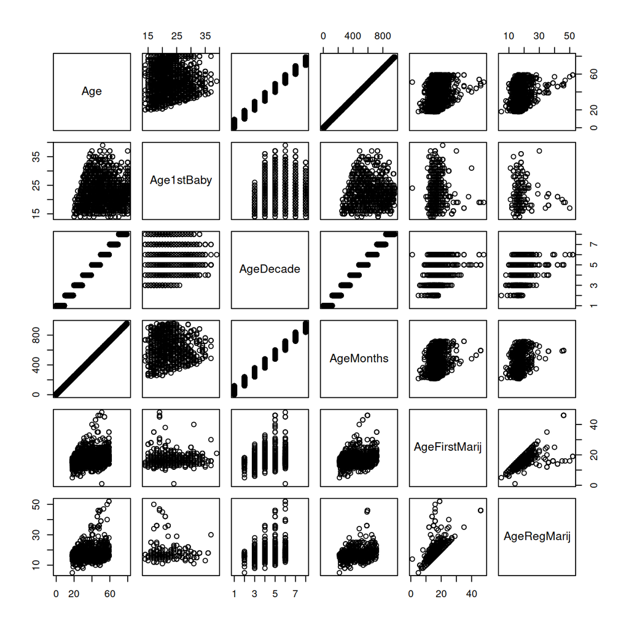

```r
pairs(subset(NHANES, select = c('Age', 'Age1stBaby', 'AgeDecade', 'AgeMonths', 'AgeFirstMarij', 'AgeRegMarij')))
```

3. Next, let’s check all variables related to alcohol:

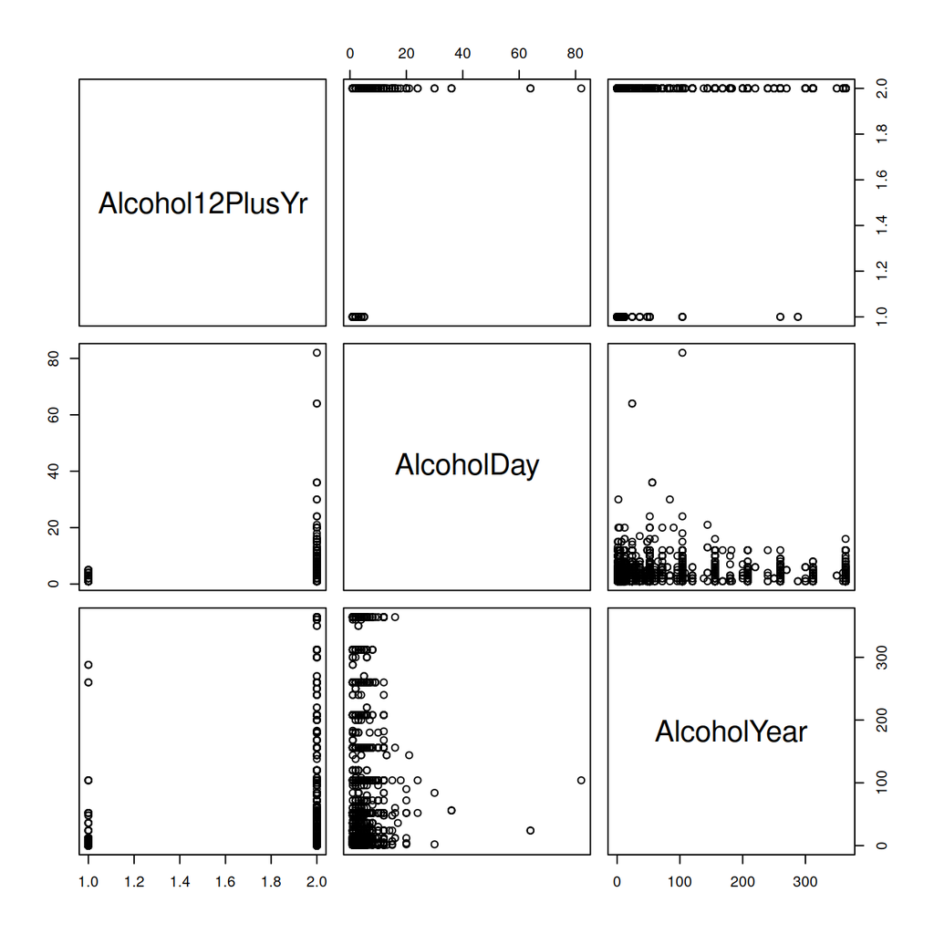

```r
to_test = c("Alcohol12PlusYr", "AlcoholDay", "AlcoholYear")
pairs(subset(NHANES, select = to_test))
```

Collinearity is not as clear in this case, but we believe one predictor related to alcohol consumption may be sufficient. We will keep `AlcoholYear`.

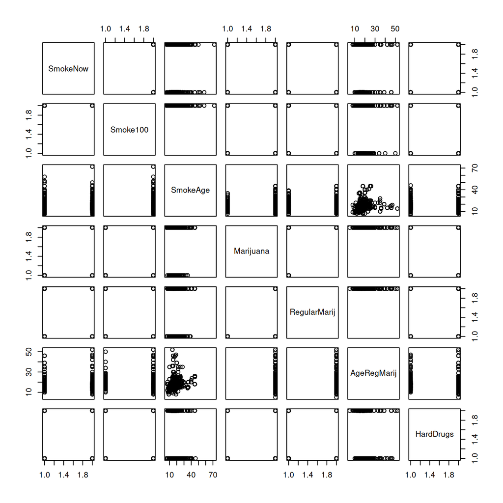

```r
to_test = c("SmokeNow", "Smoke100", "SmokeAge", "Marijuana", "RegularMarij", "AgeRegMarij", "HardDrugs")
pairs(subset(NHANES, select = to_test))
```

Most of these predictors are categorical, so collinearity cannot be seen, except for `SmokeAge` and `AgeRegMarij`. The latter makes sense as this drug is usually consumed via smoking. We can thus use one as a proxy for the other. Let’s keep `SmokeNow` and `HardDrugs` as proxies for drug abuse and its potential effect on BMI.

5. Now let’s check for collinearity between different blood pressure related variables:

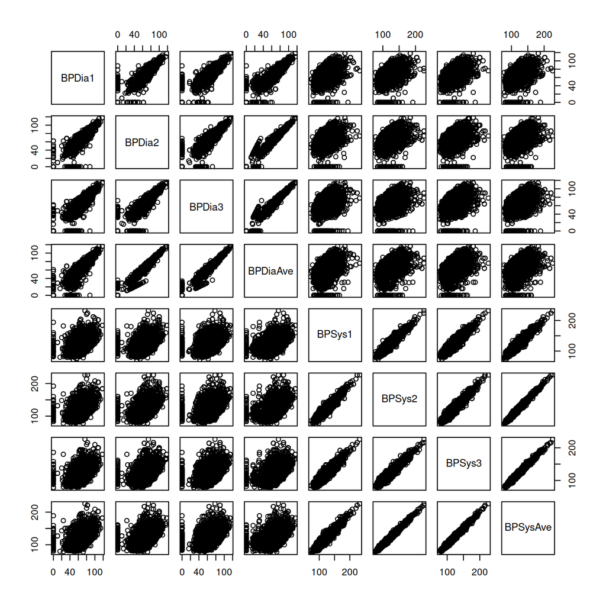

```r
to_test = c("BPDia1", "BPDia2", "BPDia3", "BPDiaAve", "BPSys1", "BPSys2", "BPSys3", "BPSysAve" )
pairs(subset(NHANES, select=to_test))
```

The blood pressure variables fall into two groups: diastolic and systolic blood pressure readings. We would expect there to be strongly collinearity within each group, which is the case. So, we only keep the average in each group `BPDiaAve` and `BPSysAve`.

6. Next, let’s investigate a few life-style variables related to being physically active or the opposite thereof, screen time:

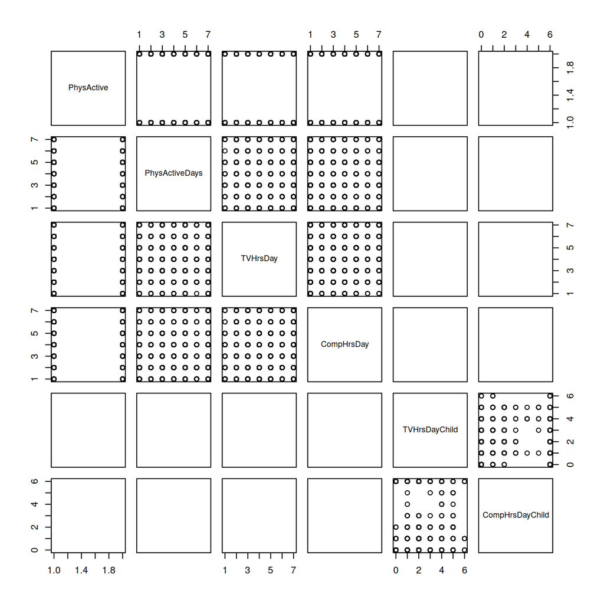

```r
to_test = c("PhysActive", "PhysActiveDays", "TVHrsDay", "CompHrsDay", "TVHrsDayChild", "CompHrsDayChild")
pairs(subset(NHANES, select=to_test))
```

Due to the nature of these variables being categorical, a clear picture of collinearity is not observable. Let’s keep half of these parameters for now, which are the ones with a bit denser levels, `PhysActiveDays`, `TVHrsDay`, `CompHrsDay`.

7. Now we should look into some other health related variables. Let’s see for cholesterol and diabetes related predictors:

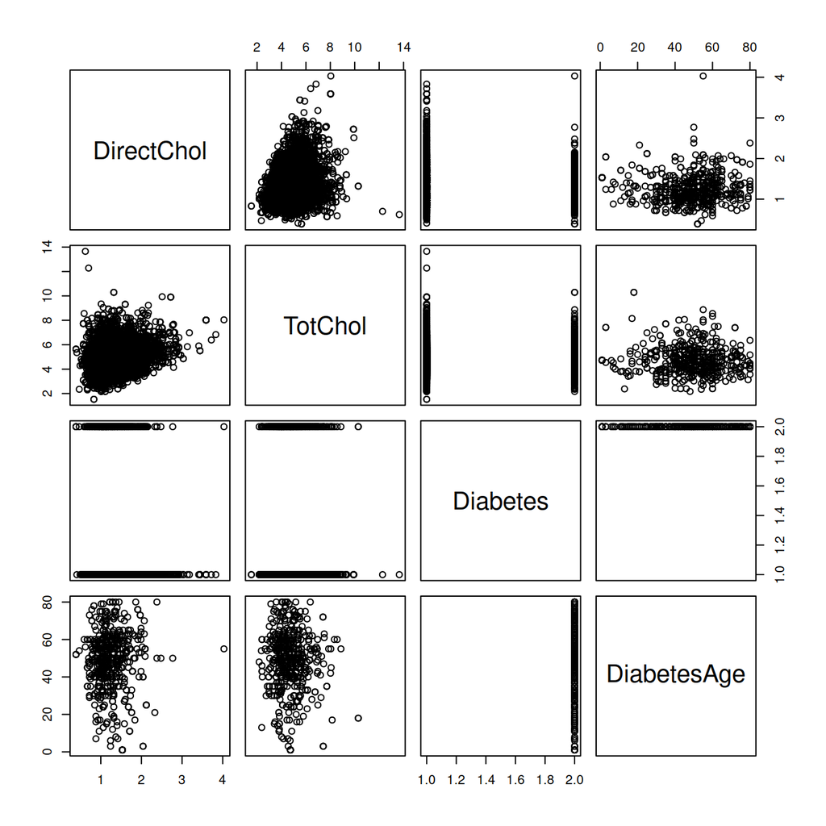

```r
to_test = c("DirectChol", "TotChol", "Diabetes", "DiabetesAge")
pairs(subset(NHANES, select = to_test))
```

`DirectChol` and `TotChol` appear to be collinear, let’s keep `TotChol`. Out of the diabetes related ones, we keep `Diabetes`.

8. Now let’s analyze more health related variables, such as those related to urogenesis below:

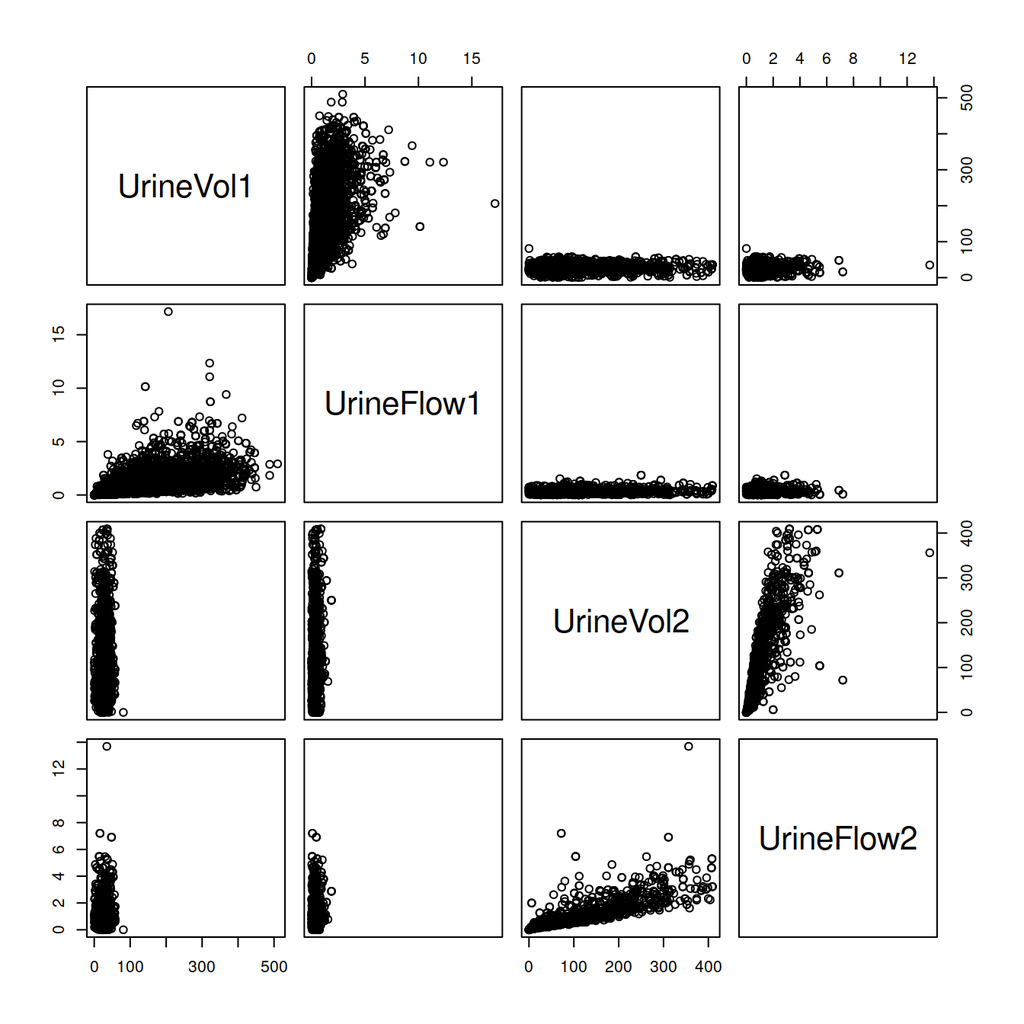

```r
to_test = c("UrineVol1", "UrineFlow1", "UrineVol2", "UrineFlow2")
pairs(subset(NHANES, select = to_test))
```

Urine volume and urine flow appear collinear. Moreover, there might be collinearity between the first and second urine measurement, respectively. Let’s keep `UrineVol1` for now.

9. Next up are a somewhat heterogenic group of variables related to health or mental health. For example, somebody who is depressed might show little interest in doing things.

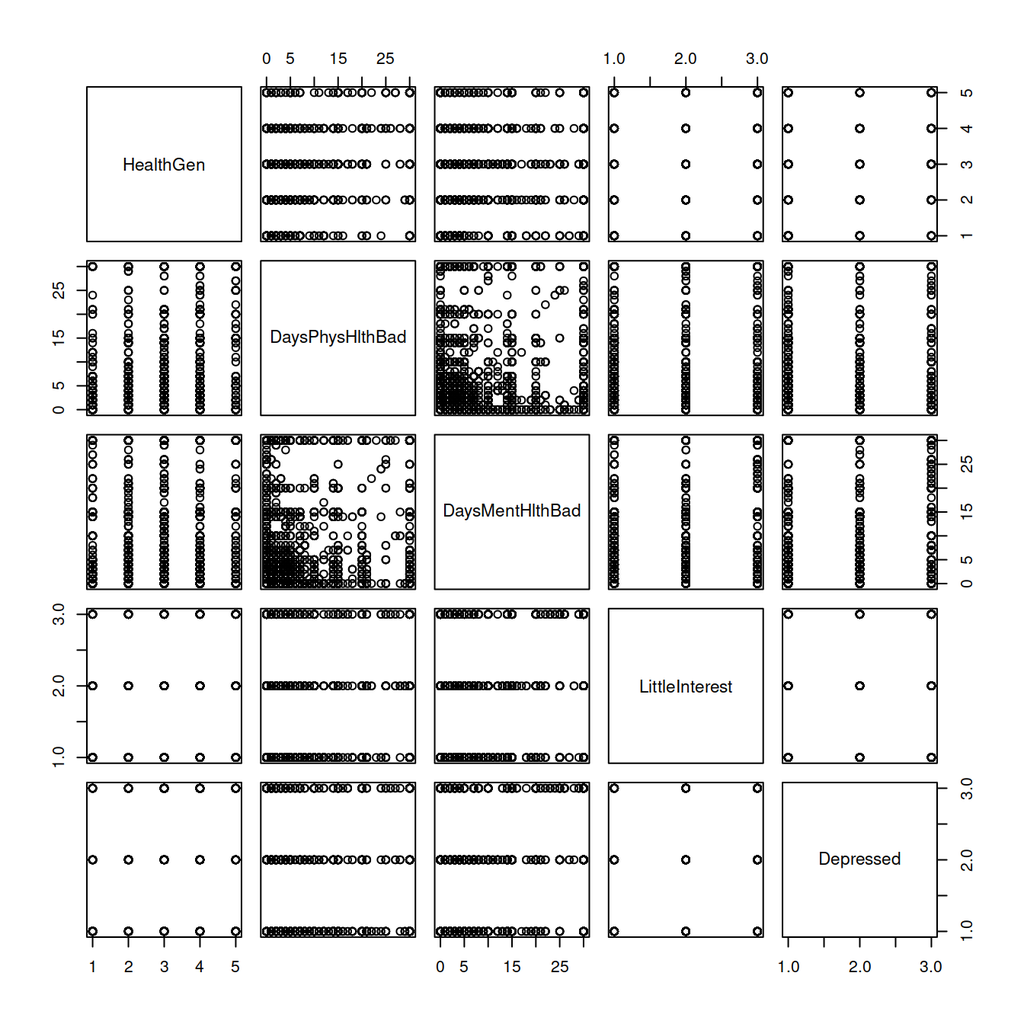

```r
to_test = c("HealthGen", "DaysPhysHlthBad", "DaysMentHlthBad", "LittleInterest", "Depressed" )
pairs(subset(NHANES, select = to_test))
```

Again, collinearity is not easy to spot in categorical variables. Let’s pick `LittleInterest` as a mild form of mental health issue (which might lead to little physical activity and obesity) and `HealthGen` as a general health rating.

10. We decided to keep `Poverty` which is a ratio of family income to poverty guidelines, and drop `HHIncomeMid` and `HHIncome`, as they both capture similar information to what the `Poverty` variable captures.
11. Finally, let’s add `nPregnancies`, `Poverty` and `SleepHrsNight` as we believe they can have an effect on BMI.

```r
#Setting up the data frames with the variables we will be excluding and keeping for model building

df_exclude = data.frame(predictor = c('Weight', 'Height', 'AgeDecade', 'AgeMonth', 'AgeRegMarij', 'Alcohol12PlusYr', 'AlcoholDay', 'Smoke100', 'SmokeAge', 'Marijuana', 'RegularMarij', "BPDia1", "BPDia2", "BPDia3", "BPSys1", "BPSys2", "BPSys3", 'PhysActive', 'TVHrsDayChild', 'CompHrsDayChild', 'DirectChol', 'DiabetesAge', "UrineFlow1", "UrineVol2", "UrineFlow2", "DaysPhysHlthBad", "DaysMentHlthBad", "Depressed"),
                        reason_to_omit = c('linear dependence with BMI','linear dependence with BMI', 'collinear with Age', 'collinear with Age', 'redundant with Marijuana', 'more sparse than AlcoholYear', 'redundant with AlcoholYear', 'redundant with SmokeNow', 'collinear with AgeRegMarij', 'redundant with AgeRegMarij, the two might be swapped', 'redundant with Marijuana', 'collinear with other blood pressure predictors', 'collinear with other blood pressure predictors', 'collinear with other blood pressure predictors', 'collinear with other blood pressure predictors', 'collinear with other blood pressure predictors', 'collinear with other blood pressure predictors', 'Redundant with PhysActiveDays', 'redundant with TVHrsDay', 'redundant with CompHrsDay', 'collinear with TotChol', 'redundant with Diabetes', 'collinear with UrineVol1', 'collinear with UrineVol1', 'collinear with UrineVol1', 'redundant with HealthGen', 'redundant with HealthGen', 'redundant with HealthGen'))

df_keep = data.frame(predictor = c('SurveyYr', 'Age', 'Age1stBaby', 'AlcoholYear', 'Marijuana', 'SmokeNow', 'HardDrugs', 'BPDiaAve', 'BPSysAve', 'PhysActiveDays', 'TVHrsDay', 'CompHrsDay', 'TotChol', 'Diabetes', 'UrineVol1', 'HealthGen', 'LittleInterest', 'nPregnancies',  'Poverty', 'SleepHrsNight' ))
#kable(df_exclude)
```

### Selected and reduced data sets

Let’s build a dataset `nhanes_select` using just those variables.

```r
nhanes_select = subset(NHANES, select =c(df_keep$predictor, "BMI"))
nrow(NHANES)
```

```
## [1] 10000
```

```r
nrow(nhanes_select)
```

```
## [1] 10000
```

We need to know which ones are categorical and turn them into factors

```r
nhanes_select$Marijuana = as.factor(nhanes_select$Marijuana)
nhanes_select$SmokeNow = as.factor(nhanes_select$SmokeNow)
nhanes_select$HardDrugs = as.factor(nhanes_select$HardDrugs)
nhanes_select$Diabetes = as.factor(nhanes_select$Diabetes)
nhanes_select$TVHrsDay = as.factor(nhanes_select$TVHrsDay)
nhanes_select$CompHrsDay = as.factor(nhanes_select$CompHrsDay)
nhanes_select$HealthGen = as.factor(nhanes_select$HealthGen)
nhanes_select$LittleInterest = as.factor(nhanes_select$LittleInterest)
#nhanes_select$Gender = as.factor(nhanes_select$Gender)
#nhanes_select$Race1 = as.factor(nhanes_select$Race1)
#nhanes_select$Education = as.factor(nhanes_select$Education)
#nhanes_select$MaritalStatus = as.factor(nhanes_select$MaritalStatus)
#nhanes_select$SleepTrouble = as.factor(nhanes_select$SleepTrouble)
```

Now it might be helpful to have a mini dataset which is devoid of NAs (missing values). We can always go back to `nhanes_select` and impute missing data. For now let’s get a quick idea of what sort of model we might get.

Furthermore, the NHANES dataset has data for 2 survey years: 2009-10 and 2011-12. To avoid including data from the same participants twice, we will further filter our dataset down by the more recent year, 2011_12.

The mini dataset after omitting missing values and filtering by a survey year is `nhanes_redux`.

```r
nhanes_redux = na.omit(nhanes_select) #removing missing values

nhanes_redux = nhanes_redux[nhanes_redux$SurveyYr == '2011_12', ] #filtering by year
nhanes_redux = subset(nhanes_redux, select = -c(SurveyYr)) #removing SurveyYr as a column for model building

#View(nhanes_redux)

n = nrow(nhanes_redux)
n
```

```
## [1] 88
```

This is very reduced at only 88 rows!

#Which variables have majority Nan values

```r
my_matrix = as.matrix(nhanes_select)

# Count the NA values in each column
na_counts = colSums(is.na(my_matrix))

# Calculate the percentage of NA values in each column
total_rows = nrow(my_matrix)
na_percentage = (na_counts / total_rows) * 100

# Create a data frame to store the results
na_summary = data.frame(Column = names(na_counts), NA_Count = na_counts, NA_Percentage = na_percentage)

# Print the summary
print(na_summary)
```

```
##                        Column NA_Count NA_Percentage
## SurveyYr             SurveyYr        0          0.00
## Age                       Age        0          0.00
## Age1stBaby         Age1stBaby     8116         81.16
## AlcoholYear       AlcoholYear     4078         40.78
## Marijuana           Marijuana     5059         50.59
## SmokeNow             SmokeNow     6789         67.89
## HardDrugs           HardDrugs     4235         42.35
## BPDiaAve             BPDiaAve     1449         14.49
## BPSysAve             BPSysAve     1449         14.49
## PhysActiveDays PhysActiveDays     5337         53.37
## TVHrsDay             TVHrsDay     5141         51.41
## CompHrsDay         CompHrsDay     5137         51.37
## TotChol               TotChol     1526         15.26
## Diabetes             Diabetes      142          1.42
## UrineVol1           UrineVol1      987          9.87
## HealthGen           HealthGen     2461         24.61
## LittleInterest LittleInterest     3333         33.33
## nPregnancies     nPregnancies     7396         73.96
## Poverty               Poverty      726          7.26
## SleepHrsNight   SleepHrsNight     2245         22.45
## BMI                       BMI      366          3.66
```

## Model building

### Redux model

We can now build a first linear regression model with all variables identified above, and test for homoskedasticity, normality and equal variance. We may also get a first impression of high influence variables and the variance inflation factor.

```r
fit_redux = lm(BMI ~ ., data = nhanes_redux)
summary(fit_redux)
```

```
##
## Call:
## lm(formula = BMI ~ ., data = nhanes_redux)
##
## Residuals:
##     Min      1Q  Median      3Q     Max
## -12.297  -2.630  -0.154   3.248  12.505
##
## Coefficients:
##                        Estimate Std. Error t value Pr(>|t|)
## (Intercept)            37.02771   14.68648    2.52   0.0147 *
## Age                    -0.01688    0.12721   -0.13   0.8949
## Age1stBaby             -0.10030    0.25646   -0.39   0.6973
## AlcoholYear            -0.01486    0.00817   -1.82   0.0746 .
## MarijuanaYes            6.44513    2.23744    2.88   0.0057 **
## SmokeNowYes            -4.29205    1.88628   -2.28   0.0269 *
## HardDrugsYes           -4.93326    2.50623   -1.97   0.0542 .
## BPDiaAve                0.01861    0.12892    0.14   0.8858
## BPSysAve                0.08309    0.11812    0.70   0.4848
## PhysActiveDays         -0.35159    0.43822   -0.80   0.4259
## TVHrsDay0_to_1_hr     -10.44242    8.18316   -1.28   0.2074
## TVHrsDay1_hr          -11.96001    8.71206   -1.37   0.1755
## TVHrsDay2_hr           -6.11731    8.33756   -0.73   0.4663
## TVHrsDay3_hr           -5.01030    8.37780   -0.60   0.5523
## TVHrsDay4_hr           -7.71466    8.46391   -0.91   0.3661
## TVHrsDayMore_4_hr      -9.71541    8.12149   -1.20   0.2368
## CompHrsDay0_to_1_hr     1.32950    2.76866    0.48   0.6330
## CompHrsDay1_hr          4.90455    2.89213    1.70   0.0957 .
## CompHrsDay2_hr          2.33489    3.06992    0.76   0.4502
## CompHrsDay3_hr         -0.58820    4.67665   -0.13   0.9004
## CompHrsDay4_hr          3.22060    4.91500    0.66   0.5151
## CompHrsDayMore_4_hr    13.05597    3.78366    3.45   0.0011 **
## TotChol                 1.13105    1.04780    1.08   0.2852
## DiabetesYes            -2.51889    3.61434   -0.70   0.4888
## UrineVol1              -0.00381    0.01293   -0.29   0.7697
## HealthGenVgood         -2.44407    4.40617   -0.55   0.5814
## HealthGenGood          -2.03938    4.54524   -0.45   0.6555
## HealthGenFair          -0.69490    5.29773   -0.13   0.8961
## HealthGenPoor          -6.11238    6.90832   -0.88   0.3802
## LittleInterestSeveral  -2.11182    3.03679   -0.70   0.4898
## LittleInterestMost      3.40516    4.88049    0.70   0.4884
## nPregnancies            0.15206    0.69855    0.22   0.8285
## Poverty                -2.27036    0.83991   -2.70   0.0092 **
## SleepHrsNight          -1.07877    0.64888   -1.66   0.1022
## ---
## Signif. codes:  0 '***' 0.001 '**' 0.01 '*' 0.05 '.' 0.1 ' ' 1
##
## Residual standard error: 5.94 on 54 degrees of freedom
## Multiple R-squared:  0.53,   Adjusted R-squared:  0.242
## F-statistic: 1.84 on 33 and 54 DF,  p-value: 0.0225
```

Let’s do some tests on this model to identify potential issues.

```r
library(lmtest)
bptest(fit_redux) #to test for constant variance
```

```
##
##  studentized Breusch-Pagan test
##
## data:  fit_redux
## BP = 49, df = 33, p-value = 0.04
```

```r
shapiro.test(resid(fit_redux)) #to test for normal distribution
```

```
##
##  Shapiro-Wilk normality test
##
## data:  resid(fit_redux)
## W = 0.99, p-value = 0.9
```

```r
cook_thresh = 4 * cooks.distance(fit_redux) / length(nhanes_redux)
mean(cooks.distance(fit_redux) > cook_thresh) #to check for influential observations
```

```
## [1] NA
```

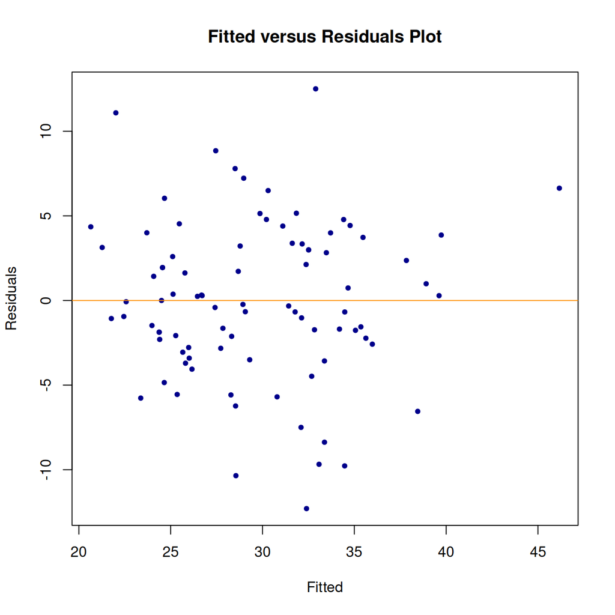

```r
#Fitted versus Residuals Plot
plot(fitted(fit_redux), resid(fit_redux), col = "darkblue", pch = 20,
     xlab = "Fitted", ylab = "Residuals", main = "Fitted versus Residuals Plot")
abline(h=0,col = "darkorange")
```

Fitted-residuals plot reveals no obvious deviation from homoskedasticity (arguably we are looking at a very small subset!). However, the p.value of the BP-test, to check for the constant variance assumption, is somewhat suspicious. The Shapiro-Wilk test does not appear suspicious, suggesting that the normality assumption is not violated.

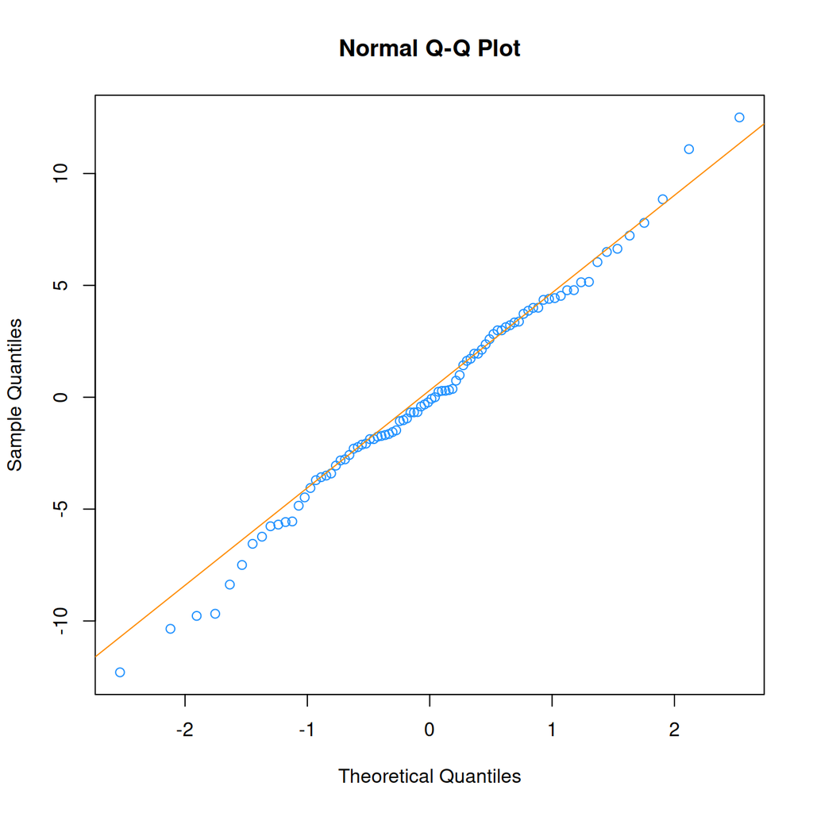

```r
#Normal Q-Q Plot
qqnorm(resid(fit_redux), col = "dodgerblue")
qqline(resid(fit_redux), col = "darkorange")
```

The Q-Q-Plot might show some deviations from normality. Again, the subset is small making it difficult to establish a pattern.

In the summary above many parameters had large p-values. Let’s check these for variance inflation.

```r
library(car)
car::vif(fit_redux)
```

```
##                  GVIF Df GVIF^(1/(2*Df))
## Age             4.015  1           2.004
## Age1stBaby      2.303  1           1.518
## AlcoholYear     1.785  1           1.336
## Marijuana       2.192  1           1.480
## SmokeNow        2.207  1           1.486
## HardDrugs       3.106  1           1.762
## BPDiaAve        2.432  1           1.559
## BPSysAve        3.250  1           1.803
## PhysActiveDays  1.614  1           1.270
## TVHrsDay       55.813  6           1.398
## CompHrsDay     29.298  6           1.325
## TotChol         2.340  1           1.530
## Diabetes        1.745  1           1.321
## UrineVol1       2.087  1           1.445
## HealthGen      24.967  4           1.495
## LittleInterest 13.699  2           1.924
## nPregnancies    1.874  1           1.369
## Poverty         4.746  1           2.179
## SleepHrsNight   1.956  1           1.399
```

Let’s do an AIC Backward model selection and check the variance inflation factor of the selected predictors again.

```r
fit_red_sel = step(fit_redux, direction = "backward", trace = 0)
summary(fit_red_sel)
```

```
##
## Call:
## lm(formula = BMI ~ AlcoholYear + Marijuana + SmokeNow + HardDrugs +
##     TVHrsDay + CompHrsDay + TotChol + Diabetes + Poverty + SleepHrsNight,
##     data = nhanes_redux)
##
## Residuals:
##     Min      1Q  Median      3Q     Max
## -11.560  -3.577  -0.505   4.098  12.959
##
## Coefficients:
##                     Estimate Std. Error t value Pr(>|t|)
## (Intercept)         35.66375    7.15031    4.99  4.6e-06 ***
## AlcoholYear         -0.01600    0.00689   -2.32   0.0233 *
## MarijuanaYes         4.74714    1.64317    2.89   0.0052 **
## SmokeNowYes         -4.25420    1.49577   -2.84   0.0059 **
## HardDrugsYes        -3.55266    1.83494   -1.94   0.0571 .
## TVHrsDay0_to_1_hr   -5.70668    6.53986   -0.87   0.3860
## TVHrsDay1_hr        -6.88381    6.72735   -1.02   0.3099
## TVHrsDay2_hr        -0.62855    6.50163   -0.10   0.9233
## TVHrsDay3_hr        -0.80212    6.61516   -0.12   0.9039
## TVHrsDay4_hr        -1.52898    6.55696   -0.23   0.8163
## TVHrsDayMore_4_hr   -3.57722    6.49009   -0.55   0.5833
## CompHrsDay0_to_1_hr  1.91472    2.18847    0.87   0.3847
## CompHrsDay1_hr       6.48359    2.25830    2.87   0.0055 **
## CompHrsDay2_hr       2.31869    2.55295    0.91   0.3670
## CompHrsDay3_hr       0.46330    3.81017    0.12   0.9036
## CompHrsDay4_hr       4.39864    4.02696    1.09   0.2786
## CompHrsDayMore_4_hr 12.75513    2.96725    4.30  5.7e-05 ***
## TotChol              1.31142    0.87734    1.49   0.1397
## DiabetesYes         -3.99335    2.97516   -1.34   0.1841
## Poverty             -2.40149    0.55733   -4.31  5.5e-05 ***
## SleepHrsNight       -0.97150    0.50819   -1.91   0.0602 .
## ---
## Signif. codes:  0 '***' 0.001 '**' 0.01 '*' 0.05 '.' 0.1 ' ' 1
##
## Residual standard error: 5.56 on 67 degrees of freedom
## Multiple R-squared:  0.489,  Adjusted R-squared:  0.337
## F-statistic: 3.21 on 20 and 67 DF,  p-value: 0.000184
```

```r
car::vif(fit_red_sel) #checking the vif from the newly fitted model.
```

```
##                GVIF Df GVIF^(1/(2*Df))
## AlcoholYear   1.451  1           1.205
## Marijuana     1.350  1           1.162
## SmokeNow      1.585  1           1.259
## HardDrugs     1.902  1           1.379
## TVHrsDay      7.646  6           1.185
## CompHrsDay    5.445  6           1.152
## TotChol       1.874  1           1.369
## Diabetes      1.351  1           1.162
## Poverty       2.387  1           1.545
## SleepHrsNight 1.370  1           1.171
```

As far as VIF is concerned this mini-model has improved over `fit_redux` The p-value of the overall model also results in a rejection of the null hypothesis, and shows that the regression is significant. However, most of the individual predictors are not significant in this model prompting us to investigate further regarding model selection.

Since we suspect the constant variance assumption may be violated, we next attempt a log transformation of the response as well as all two-way interactions. However, a lot of the two-way interactions gave us NA for coefficients, most likely due to the presence of categorical variables. We therefore limited the interaction to be that of Age with all the other variables except TVHrsDay which also resulted in an NA. We followed this with a backwards search with both AIC and BIC.

```r
#Function to calculate the LOOCVRMSE
calc_loocv_rmse = function(model) {
  sqrt(mean((resid(model) / (1 - hatvalues(model))) ^ 2))
}

#Fitting the initial model with a log transformation of the response and some interactions
fit_redux_transform_Age_int = lm(log(BMI) ~ . + Age:. - Age:TVHrsDay, data = nhanes_redux)
#summary(fit_redux_transform_Age_int)

#AIC backwards search
fit_red_sel_aic = step(fit_redux_transform_Age_int, direction = "backward", trace = 0)
summary(fit_red_sel_aic)
```

```
##
## Call:
## lm(formula = log(BMI) ~ Age + Age1stBaby + Marijuana + SmokeNow +
##     HardDrugs + BPDiaAve + BPSysAve + TVHrsDay + CompHrsDay +
##     TotChol + Diabetes + HealthGen + LittleInterest + nPregnancies +
##     Poverty + SleepHrsNight + Age:Age1stBaby + Age:Marijuana +
##     Age:SmokeNow + Age:BPDiaAve + Age:BPSysAve + Age:CompHrsDay +
##     Age:Diabetes + Age:HealthGen + Age:LittleInterest + Age:nPregnancies +
##     Age:Poverty + Age:SleepHrsNight, data = nhanes_redux)
##
## Residuals:
##      Min       1Q   Median       3Q      Max
## -0.27303 -0.03644  0.00432  0.05529  0.19151
##
## Coefficients:
##                            Estimate Std. Error t value Pr(>|t|)
## (Intercept)               -4.744968   2.298143   -2.06  0.04621 *
## Age                        0.174685   0.051845    3.37  0.00181 **
## Age1stBaby                -0.050271   0.041567   -1.21  0.23439
## MarijuanaYes              -1.473909   0.578543   -2.55  0.01526 *
## SmokeNowYes                0.346853   0.352967    0.98  0.33232
## HardDrugsYes              -0.138309   0.092672   -1.49  0.14429
## BPDiaAve                  -0.103401   0.025707   -4.02  0.00028 ***
## BPSysAve                   0.093346   0.021684    4.30  0.00012 ***
## TVHrsDay0_to_1_hr         -0.452289   0.266380   -1.70  0.09815 .
## TVHrsDay1_hr              -0.395155   0.263199   -1.50  0.14198
## TVHrsDay2_hr              -0.299995   0.276269   -1.09  0.28475
## TVHrsDay3_hr              -0.237906   0.273567   -0.87  0.39026
## TVHrsDay4_hr              -0.097170   0.273283   -0.36  0.72424
## TVHrsDayMore_4_hr         -0.183386   0.248650   -0.74  0.46558
## CompHrsDay0_to_1_hr        1.707624   0.518355    3.29  0.00222 **
## CompHrsDay1_hr             0.303148   0.511548    0.59  0.55715
## CompHrsDay2_hr             1.028846   0.684167    1.50  0.14136
## CompHrsDay3_hr             0.501145   0.625552    0.80  0.42832
## CompHrsDay4_hr             0.631918   1.476388    0.43  0.67119
## CompHrsDayMore_4_hr        2.533129   0.947806    2.67  0.01124 *
## TotChol                   -0.034465   0.035072   -0.98  0.33231
## DiabetesYes               -2.253457   1.004622   -2.24  0.03114 *
## HealthGenVgood             3.438737   1.318130    2.61  0.01315 *
## HealthGenGood              4.286132   1.548585    2.77  0.00886 **
```

[output cut: 19 more lines]

```
## Age:HealthGenVgood        -0.077144   0.033420   -2.31  0.02684 *
## Age:HealthGenGood         -0.093622   0.037731   -2.48  0.01790 *
## Age:HealthGenFair         -0.067220   0.033948   -1.98  0.05538 .
## Age:HealthGenPoor         -0.099932   0.038064   -2.63  0.01263 *
## Age:LittleInterestSeveral  0.031878   0.019379    1.64  0.10868
## Age:LittleInterestMost    -0.006130   0.014374   -0.43  0.67230
## Age:nPregnancies          -0.006998   0.002644   -2.65  0.01197 *
## Age:Poverty                0.004651   0.003899    1.19  0.24068
## Age:SleepHrsNight         -0.009503   0.004578   -2.08  0.04515 *
## ---
## Signif. codes:  0 '***' 0.001 '**' 0.01 '*' 0.05 '.' 0.1 ' ' 1
##
## Residual standard error: 0.138 on 36 degrees of freedom
## Multiple R-squared:  0.848,  Adjusted R-squared:  0.633
## F-statistic: 3.95 on 51 and 36 DF,  p-value: 0.0000193
```

```r
calc_loocv_rmse(fit_red_sel_aic) #Calculating the LOOCV RMSE
```

```
## [1] Inf
```

```r
#BIC backwards search
n = length(resid(fit_redux_transform_Age_int))
fit_red_sel_bic = step(fit_redux_transform_Age_int, direction = "backward",
                            k = log(n), trace = 0)
summary(fit_red_sel_bic)
```

```
##
## Call:
## lm(formula = log(BMI) ~ Age + Age1stBaby + AlcoholYear + Marijuana +
##     BPSysAve + UrineVol1 + nPregnancies + Poverty + SleepHrsNight +
##     Age:Age1stBaby + Age:AlcoholYear + Age:BPSysAve + Age:UrineVol1 +
##     Age:nPregnancies + Age:SleepHrsNight, data = nhanes_redux)
##
## Residuals:
##     Min      1Q  Median      3Q     Max
## -0.6345 -0.0933  0.0066  0.1198  0.3786
##
## Coefficients:
##                     Estimate Std. Error t value Pr(>|t|)
## (Intercept)       -4.3960088  1.3969986   -3.15  0.00240 **
## Age                0.1770093  0.0301280    5.88  1.2e-07 ***
## Age1stBaby        -0.0538262  0.0266156   -2.02  0.04685 *
## AlcoholYear       -0.0035438  0.0010814   -3.28  0.00162 **
## MarijuanaYes       0.1512915  0.0487026    3.11  0.00271 **
## BPSysAve           0.0511519  0.0104620    4.89  6.0e-06 ***
## UrineVol1          0.0046979  0.0015263    3.08  0.00295 **
## nPregnancies       0.2846478  0.0734912    3.87  0.00023 ***
## Poverty           -0.0502416  0.0147308   -3.41  0.00107 **
## SleepHrsNight      0.2512414  0.0769927    3.26  0.00169 **
## Age:Age1stBaby     0.0012446  0.0005938    2.10  0.03960 *
## Age:AlcoholYear    0.0000645  0.0000220    2.93  0.00455 **
## Age:BPSysAve      -0.0011694  0.0002301   -5.08  2.8e-06 ***
## Age:UrineVol1     -0.0001152  0.0000349   -3.30  0.00151 **
## Age:nPregnancies  -0.0057600  0.0015959   -3.61  0.00056 ***
## Age:SleepHrsNight -0.0057538  0.0017083   -3.37  0.00122 **
## ---
## Signif. codes:  0 '***' 0.001 '**' 0.01 '*' 0.05 '.' 0.1 ' ' 1
##
## Residual standard error: 0.168 on 72 degrees of freedom
## Multiple R-squared:  0.551,  Adjusted R-squared:  0.457
## F-statistic: 5.88 on 15 and 72 DF,  p-value: 9.81e-08
```

```r
calc_loocv_rmse(fit_red_sel_bic) #Calculating the LOOCV RMSE
```

```
## [1] 0.1796
```

After calculating the LOOCV RMSE, we see that the model chosen using BIC performs the best. It is therefore both the best model for prediction, as it has the best LOOCV RMSE and also the best model for explanation, as it is the smallest.

## Where to go from here

- The `nhanes_redux` is really tiny. We want to think about a better strategy for dealing with NAs rather than just omitting 99% of the data.
- Once we can fit `nhanes_select_clean` we can run step-wise search again to find a reasonably good model and do the linear model tests as above again.
- Note: adding ‘Gender’, ‘Race1’, ‘Education’, ‘MaritalStatus’, ‘SleepTrouble’, ‘Pulse’ was resulting in an adjusted R-squared of 1, and loocv_rmse = Inf in the final models. If we want, we can re-try adding them or a couple of them again to see what this is happening in more detail and why.
- We could also then check for partial correlation for some predictors (with high VIF?).
- …